# Rompiendo Estereotipos sobre los fanáticos del anime en Lima

30/09/2022

# **1. Introducción:**

## Relevancia

Los estereotipos son negativos, positivos o neutros, pero en cualquier caso marcan los roles que puede desempeñar una persona en un grupo social generando en muchos casos situaciones de desigualdad y discriminación. Por ejemplo, socialmente, a los “otakus” se les asocia con la imagen de personas que no se asean hasta personas introvertidas e incluso “agresivas”. Estos prejuicios podría ocasionar que sea excluido de grupos de trabajo o que tenga que renunciar a sus preferencias con tal de ser aceptado por el entorno que no comparte los mismos gustos.

```r
# Instalar ggplot2 si no está instalado
if(! require(ggplot2)){install.packages("ggplot2")}
```

# **2. Datos:**

## Proceso de recolección de datos

La recolección de datos se realizó mediante la elaboración de una encuesta en google forms. Al ser esta una herramienta virtual, nos da la facilidad de encuestar tanto de forma presencial, como virtual

El proceso que se llevó a cabo para la obtención de los datos fue el siguiente:

1. Primero, se redactaron las preguntas y se diseñó la encuesta de tal forma que la cantidad de errores al ser respondidas sea lo menor posible. De esta forma, el análisis y los resultados no serán influenciados negativamente.
2. Una vez terminada la encuesta, durante tres semanas, los integrantes del grupo asistieron a zonas donde los otakus asisten con mayor frecuencia para poder llevar a cabo la recolección de datos.
3. Al mismo tiempo, se compartió el enlace de la encuesta en grupos de facebook, whatsapp u otras redes, para poder tener un mayor alcance y obtener más respuestas en menos tiempo.

## Población, muestra y muestreo

1. *Población:*

   En este caso nuestra población son todas aquellas personas de Lima que se consideren fanáticos del anime o que en algún momento lo fueron sean o no parte de la comunidad Otaku y que residan en la ciudad de Lima.
2. *Muestra y Muestreo:*

   A continuación podemos apreciar los lugares en los que se recolectó la información y la cantidad que se logró recolectar por cada medio además de su relevancia:
- Centro Comercial - 50 encuestas realizadas
- Alameda 28 de Julio - 30 encuestas realizadas
- Recolección virtual - 123 encuestas realizadas

## Variables

| **N°** | **Variable** | **Tipo de variable** |
| --- | --- | --- |
| 1 | Sexo | Nominal |
| 2 | Edad | Discreta |
| 3 | Altura | Continua |
| 4 | Escolaridad | Ordinal |
| 5 | Distrito | Nominal |
| 6 | Otaku | Nominal |
| 7 | Año_fan | Nominal |
| 8 | Genero_anime | Nominal |
| 9 | Clasico | Nominal |
| 10 | Cantidad_horas | Continua |
| 11 | Cantidad_anime | Discreta |
| 12 | Manga | Nominal |
| 13 | Ducha | Ordinal |
| 14 | Caracteristica | Nominal |
| 15 | Pareja | Nominal |
| 16 | Madurez | Nominal |
| 17 | Deporte | Nominal |
| 18 | Cabello_pintado | Nominal |
| 19 | Ropa_anime | Ordinal |
| 20 | Interaccion | Nominal |
| 21 | Reuniones | Ordinal |
| 22 | Festivales | Nominal |
| 23 | Genero_musica | Nominal |

## Limpieza de base de datos

Antes de realizar cualquier modificación al data frame, debemos instalar y cargar las librerías necesaria para poder leer y modificar el archivo .csv

```r
# Instalar y cargar librería "readr" y "dplyr"
if(! require(readr)){install.packages("readr")}
if(! require(dplyr)){install.packages("dplyr")}
# Cargar el archivo .csv en una variable
DF <- read_csv("Estereotipos.csv")
head(DF)
```

| Marca temporal | Género | Edad | Altura | Escolaridad | ¿En qué distrito de Lima vives actualmente? | ¿Te considerás otaku? | ¿Desde que año empezaste a ver animes? | Género Favorito de Anime | ¿Cuál es tu anime clásico favorito? | ¿Cuantás horas de anime ves al día? | ¿Cuantós animes ves en un mes? | ¿Lees mangas? | ¿Te consideras extrovertido o introvertido? | ¿Qué tan frecuentemente tomas una ducha? | ¿Tienes pareja? | ¿Te consideras una persona madura? | ¿Realizas algun deporte? | ¿Alguna vez te has pintado el cabello? | ¿Con qué frecuencia usas ropa relacionada al anime? | ¿Cómo prefieres interactuar con las personas? | ¿Con que frecuencia sales a fiestas o reuniones sociales? | ¿Participas de festivales de Anime? | ¿Qué género de música escuchas? |
| --- | --- | --- | --- | --- | --- | --- | --- | --- | --- | --- | --- | --- | --- | --- | --- | --- | --- | --- | --- | --- | --- | --- | --- |
| 16/09/2022 18:48:50 | Masculino | 19 | 175 | Universidad privada | Santiago de Surco | Sí | 2014 | Cyber Punk, Seinen | Pokémon | 2 | 4 | Sí | Introvertido | 4 | No | No | Sí | No | 1 | Presencial (Cara a cara) | 3 | No | Rock o Hard Rock |
| 16/09/2022 20:33:07 | Femenino | 20 | 172 | Instituto privado | Santiago de Surco | Sí | 2010 | Otros | Jujutsu kaizen | 1 | 2 | Sí | Introvertido | 5 | No | No | Sí | Sí | 2 | Presencial (Cara a cara) | 1 | No | K-pop |
| 16/09/2022 20:33:25 | Femenino | 20 | 157 | Universidad privada | Miraflores | No | 2017 | Otros | Death note | 1 | 1 | No | Extrovertido | 4 | No | Sí | Sí | Sí | 1 | Presencial (Cara a cara) | 4 | Sí | K-pop |
| 16/09/2022 20:33:48 | Femenino | 23 | 161 | Universidad privada | Santiago de Surco | Sí | 2019 | Shounen, Yaoi | Death Note | 4 | 3 | Sí | Introvertido | 5 | No | No | Sí | Sí | 3 | Presencial (Cara a cara) | 4 | Sí | Pop |
| 16/09/2022 20:40:26 | Femenino | 33 | 159 | Universidad privada | Pueblo libre | No | 2019 | Otros | Saylor moon | 1 | 1 | Sí | Introvertido | 5 | Sí | Sí | No | Sí | 1 | Presencial (Cara a cara) | 4 | Sí | K-pop |
| 16/09/2022 20:40:51 | Femenino | 22 | 157 | Instituto privado | Pueblo libre | Sí | 2012 | Yaoi | Death Note | 1 | 3 | Sí | Introvertido | 5 | No | Sí | Sí | Sí | 3 | Presencial (Cara a cara) | 3 | Sí | K-pop |

A continuación, se mencionaran los criterios usados para limpiar de tal forma que a realizar el análisis descriptivo, los errores sean mínimos:

- *Eliminacón de columna innecesaria:*

  El data frame original contiene una columna que muestra el momento en el que se relleo la encuesta, esta variable es innecesaria para el análisis descriptivo posterior; es por eso, que debe ser eliminada.

| Género | Edad | Altura | Escolaridad | ¿En qué distrito de Lima vives actualmente? | ¿Te considerás otaku? | ¿Desde que año empezaste a ver animes? | Género Favorito de Anime | ¿Cuál es tu anime clásico favorito? | ¿Cuantás horas de anime ves al día? | ¿Cuantós animes ves en un mes? | ¿Lees mangas? | ¿Te consideras extrovertido o introvertido? | ¿Qué tan frecuentemente tomas una ducha? | ¿Tienes pareja? | ¿Te consideras una persona madura? | ¿Realizas algun deporte? | ¿Alguna vez te has pintado el cabello? | ¿Con qué frecuencia usas ropa relacionada al anime? | ¿Cómo prefieres interactuar con las personas? | ¿Con que frecuencia sales a fiestas o reuniones sociales? | ¿Participas de festivales de Anime? | ¿Qué género de música escuchas? |
| --- | --- | --- | --- | --- | --- | --- | --- | --- | --- | --- | --- | --- | --- | --- | --- | --- | --- | --- | --- | --- | --- | --- |
| Masculino | 19 | 175 | Universidad privada | Santiago de Surco | Sí | 2014 | Cyber Punk, Seinen | Pokémon | 2 | 4 | Sí | Introvertido | 4 | No | No | Sí | No | 1 | Presencial (Cara a cara) | 3 | No | Rock o Hard Rock |
| Femenino | 20 | 172 | Instituto privado | Santiago de Surco | Sí | 2010 | Otros | Jujutsu kaizen | 1 | 2 | Sí | Introvertido | 5 | No | No | Sí | Sí | 2 | Presencial (Cara a cara) | 1 | No | K-pop |
| Femenino | 20 | 157 | Universidad privada | Miraflores | No | 2017 | Otros | Death note | 1 | 1 | No | Extrovertido | 4 | No | Sí | Sí | Sí | 1 | Presencial (Cara a cara) | 4 | Sí | K-pop |
| Femenino | 23 | 161 | Universidad privada | Santiago de Surco | Sí | 2019 | Shounen, Yaoi | Death Note | 4 | 3 | Sí | Introvertido | 5 | No | No | Sí | Sí | 3 | Presencial (Cara a cara) | 4 | Sí | Pop |
| Femenino | 33 | 159 | Universidad privada | Pueblo libre | No | 2019 | Otros | Saylor moon | 1 | 1 | Sí | Introvertido | 5 | Sí | Sí | No | Sí | 1 | Presencial (Cara a cara) | 4 | Sí | K-pop |
| Femenino | 22 | 157 | Instituto privado | Pueblo libre | Sí | 2012 | Yaoi | Death Note | 1 | 3 | Sí | Introvertido | 5 | No | Sí | Sí | Sí | 3 | Presencial (Cara a cara) | 3 | Sí | K-pop |

- *Cambio de los encabezados:*

  Originalmente, el archivo .csv que se usó como data frame tenía como encabezado las preguntas realizadas durante la encuesta, debido a ello es que se optó por cambiarlos por nombres de variables que faciliten el manejo de los datos dentro del ambiente de RStudio.

```r
# Identificar los nombres de los encabezados
colnames(DF1)
```

```
##  [1] "Género"
##  [2] "Edad"
##  [3] "Altura"
##  [4] "Escolaridad"
##  [5] "¿En qué distrito de Lima vives actualmente?"
##  [6] "¿Te considerás otaku?"
##  [7] "¿Desde que año empezaste a ver animes?"
##  [8] "Género Favorito de Anime"
##  [9] "¿Cuál es tu anime clásico favorito?"
## [10] "¿Cuantás horas de anime ves al día?"
## [11] "¿Cuantós animes ves en un mes?"
## [12] "¿Lees mangas?"
## [13] "¿Te consideras extrovertido o introvertido?"
## [14] "¿Qué tan frecuentemente tomas una ducha?"
## [15] "¿Tienes pareja?"
## [16] "¿Te consideras una persona madura?"
## [17] "¿Realizas algun deporte?"
## [18] "¿Alguna vez te has pintado el cabello?"
## [19] "¿Con qué frecuencia usas ropa relacionada al anime?"
## [20] "¿Cómo prefieres interactuar con las personas?"
## [21] "¿Con que frecuencia sales a fiestas o reuniones sociales?"
## [22] "¿Participas de festivales de Anime?"
## [23] "¿Qué género de música escuchas?"
```

```r
# Cambiar encabezados
DF1 <- rename(DF1, Sexo = 'Género', Edad = 'Edad', Altura = 'Altura', Escolaridad = 'Escolaridad', Distrito = '¿En qué distrito de Lima vives actualmente?', Otaku = '¿Te considerás otaku?', Año_Fan = '¿Desde que año empezaste a ver animes?', Genero_Anime = 'Género Favorito de Anime', Clasico = '¿Cuál es tu anime clásico favorito?', Cantidad_Horas = '¿Cuantás horas de anime ves al día?', Cantidad_Anime = '¿Cuantós animes ves en un mes?', Manga = '¿Lees mangas?', Caracteristica = '¿Te consideras extrovertido o introvertido?', Ducha = '¿Qué tan frecuentemente tomas una ducha?', Pareja = '¿Tienes pareja?', Madurez = '¿Te consideras una persona madura?', Deporte = '¿Realizas algun deporte?',Cabello_Pintado = '¿Alguna vez te has pintado el cabello?', Ropa_Anime = '¿Con qué frecuencia usas ropa relacionada al anime?', Interaccion = '¿Cómo prefieres interactuar con las personas?', Reuniones = '¿Con que frecuencia sales a fiestas o reuniones sociales?', Festivales = '¿Participas de festivales de Anime?', Genero_Musica = '¿Qué género de música escuchas?')
```

```r
# Corroborar el cambio
colnames(DF1)
```

```
##  [1] "Sexo"            "Edad"            "Altura"          "Escolaridad"
##  [5] "Distrito"        "Otaku"           "Año_Fan"         "Genero_Anime"
##  [9] "Clasico"         "Cantidad_Horas"  "Cantidad_Anime"  "Manga"
## [13] "Caracteristica"  "Ducha"           "Pareja"          "Madurez"
## [17] "Deporte"         "Cabello_Pintado" "Ropa_Anime"      "Interaccion"
## [21] "Reuniones"       "Festivales"      "Genero_Musica"
```

- *Correción de los datos de las variables:*

  Clásico es una variable que contiene datos sobre el nombre del anime clásico favorito de la persona encuestada. Al ser una pregunta abierta, la persona redacta dicha respuesta, debido a ello hay personas que usan mayúsculas y otras no por lo que se generan datos repetidos pero a la vez diferentes.

En primer lugar, se corregiran los datos en la variable *Año_Fan* ya que se pueden observar muchas formas en la que se da a entender que la persona encuestada no ve animes.

```r
DF1 %>% count(Año_Fan)
```

| Año_Fan | n |
| --- | --- |
| 0 | 6 |
| 1992 | 2 |
| 1995 | 2 |
| 1996 | 1 |
| 1998 | 1 |
| 1999 | 1 |
| 2000 | 3 |
| 2001 | 2 |
| 2002 | 2 |
| 2003 | 1 |

[output cut: 28 more lines]

```r
DF1 %>% mutate(Año_Fan =
        ifelse(Año_Fan %in% c("0", "De hecho no miro, pero algunos si pero no soy otaku", "Ninguno", "No lo soy", "No soy fan", "No soy fan, sólo lo veo como cualquier otra serie", "No tengo", "No veo animes."), "Nunca",
        ifelse(Año_Fan %in% c("Hace 2 años"), "2020", Año_Fan
        ))) -> DF1
```

```r
DF1 %>% count(Año_Fan)
```

| Año_Fan | n |
| --- | --- |
| 1992 | 2 |
| 1995 | 2 |
| 1996 | 1 |
| 1998 | 1 |
| 1999 | 1 |
| 2000 | 3 |
| 2001 | 2 |
| 2002 | 2 |
| 2003 | 1 |
| 2004 | 2 |

[output cut: 19 more lines]

También, se deben corregir los datos de los nombres de los animes obtenidos al preguntar sobre cuál es el anime clásico favorito de la persona en cuestión.

```r
DF1 %>% count(Clasico)
```

| Clasico | n |
| --- | --- |
| Another | 1 |
| Attack of titans | 1 |
| Attack on titan | 1 |
| Berserk | 1 |
| Bleach | 1 |
| Boku no Hero Academy | 1 |
| Boku no hero academia | 1 |
| Boku no hero academy | 1 |
| Candi | 1 |
| Candy | 2 |

[output cut: 112 more lines]

[figure not shown]

Fig. 7: Datos de la variable clasico Originales

```r
DF1 %>% mutate(Clasico =
        ifelse(Clasico %in% c("Attack of titans", "attack on titan", "Attack on titan", "SNK"), "Shingeki no Kyojin",
        ifelse(Clasico %in% c("Boku no hero academia", "Boku no hero academy", "My Hero Academia"), "Boku no Hero Academy",
        ifelse(Clasico %in% c("Candi"), "Candy",
        ifelse(Clasico %in% c("cero", "Zero no Tsikaima"), "Zero no Tsukaima",
        ifelse(Clasico %in% c("code geass", "Code gueass"), "Code Geass",
        ifelse(Clasico %in% c("death note", "Death note"), "Death Note",
        ifelse(Clasico %in% c("Digimón", "digimon"), "Digimon",
        ifelse(Clasico %in% c("Dragon ball", "Dragón ball", "Dragón Ball", "Dragón boll", "dragonball"), "Dragon Ball",
        ifelse(Clasico %in% c("Dragon ball z", "Dragón ball Z", "Dbz"), "Dragon Ball Z",
        ifelse(Clasico %in% c("Full metal Alchemist", "Full Metal Alchemist", "Fullmetal alchemist"), "Fullmetal Alchemist",
        ifelse(Clasico %in% c("gintama"), "Gintama",
        ifelse(Clasico %in% c("great teacher onizuka"), "Great teacher onizuka",
        ifelse(Clasico %in% c("haikyuu", "Haikyuu"), "Haikyu",
        ifelse(Clasico %in% c("Hunter Hunter", "hunter x hunter"), "Hunter x Hunter",
        ifelse(Clasico %in% c("inuyasha"), "Inuyasha",
        ifelse(Clasico %in% c("jojo's bizarre adventure","Jojos"), "JoJo's Bizarre Adventure",
        ifelse(Clasico %in% c("Los Súper Campeones","Los Súper Campeones", "Los super campeones"), "Captain Tsubasa",
        ifelse(Clasico %in% c("naruto"), "Naruto",
        ifelse(Clasico %in% c("Naruto Shipuden"), "Naruto Shippuden",
        ifelse(Clasico %in% c("Neon Genesis Evangelion"), "Evangelion",
        ifelse(Clasico %in% c("once pice", "one piece", "One piece", "one piece y dragón ball"), "One Piece",
        ifelse(Clasico %in% c("parasyte"), "Parasyte",
        ifelse(Clasico %in% c("Picachu", "Pokémon"), "Pokemon",
        ifelse(Clasico %in% c("saber mationette j to x"), "Saber Marionette J to X",
        ifelse(Clasico %in% c("Sailor moon", "Saylor moon", "Saylor Moon"), "Sailor Moon",
        ifelse(Clasico %in% c("sakura card captors"), "Sakura Card Captor",
        ifelse(Clasico %in% c("shigatsu wa kimi no uso", "Shigatsu wa kimi no uso", "Shigatsu wa Kimi no uso", "Shigatsu Wa Kimi no Uso"), "Shigatsu wa Kimi no Uso",
        ifelse(Clasico %in% c("Tokyo ghoul", "Tokio Ghoul", "Tokyo goul"), "Tokyo Ghoul",
        ifelse(Clasico %in% c("Your lie in april"), "Your lie in April",
        ifelse(Clasico %in% c("Yugioh"), "Yu-Gi-Oh",
        ifelse(Clasico %in% c("re main"), "Re-Main",
        ifelse(Clasico %in% c("Cowboy bebop, Fullmetal alchemist, Elfen lied"), "Cowboy Bebop",
        ifelse(Clasico %in% c("another"), "Another",
        ifelse(Clasico %in% c("español"), "Español",
        ifelse(Clasico %in% c("N.A", "ninguno", "Ninguni", "No tengo", "No tengo anime favorito", "No tengo."), "Ninguno", Clasico
        )))))))))))))))))))))))))))))))))))) -> DF1
```

```r
DF1 %>% count(Clasico)
```

| Clasico | n |
| --- | --- |
| Another | 2 |
| Berserk | 1 |
| Bleach | 1 |
| Boku no Hero Academy | 4 |
| Candy | 3 |
| Captain Tsubasa | 2 |
| Code Geass | 3 |
| Cowboy Bebop | 1 |
| Death Note | 19 |
| Digimon | 5 |

[output cut: 57 more lines]

# **4. Análisis descriptivo:**

- Para poder realizar el analisis con los descriptores numericos sera necesario convertir las variables a sus tipos correctos utilizando los siguientes comando convertiremos “Año_Fan” y “Cantidad_Horas” de Character a Numeric

```r
DF1$Año_Fan <- as.numeric(DF1$Año_Fan)
DF1$Cantidad_Horas <- as.numeric(DF1$Cantidad_Horas)
```

```r
DF1 <- DF1[DF1$Año_Fan!=0,]
```

- A continuacio se muestra el resumen de las variables indicando sus tipos respectivos

```r
summary(DF1)
```

```
##      Sexo                Edad           Altura      Escolaridad
##  Length:217         Min.   :11.00   Min.   :145.0   Length:217
##  Class :character   1st Qu.:18.00   1st Qu.:159.0   Class :character
##  Mode  :character   Median :19.00   Median :166.5   Mode  :character
##                     Mean   :20.62   Mean   :165.9
##                     3rd Qu.:22.00   3rd Qu.:172.0
##                     Max.   :55.00   Max.   :187.0
##                     NA's   :15      NA's   :15
##    Distrito            Otaku              Año_Fan     Genero_Anime
##  Length:217         Length:217         Min.   :1992   Length:217
##  Class :character   Class :character   1st Qu.:2009   Class :character
##  Mode  :character   Mode  :character   Median :2012   Mode  :character
##                                        Mean   :2012
##                                        3rd Qu.:2017
##                                        Max.   :2022
##                                        NA's   :15
##    Clasico          Cantidad_Horas  Cantidad_Anime      Manga
##  Length:217         Min.   :0.000   Min.   : 0.000   Length:217
##  Class :character   1st Qu.:1.000   1st Qu.: 1.000   Class :character
##  Mode  :character   Median :1.000   Median : 2.000   Mode  :character
##                     Mean   :1.299   Mean   : 2.134
##                     3rd Qu.:2.000   3rd Qu.: 2.000
##                     Max.   :5.000   Max.   :10.000
##                     NA's   :20      NA's   :15
##  Caracteristica         Ducha          Pareja            Madurez
##  Length:217         Min.   :1.000   Length:217         Length:217
##  Class :character   1st Qu.:4.000   Class :character   Class :character
##  Mode  :character   Median :4.000   Mode  :character   Mode  :character
##                     Mean   :4.139
##                     3rd Qu.:5.000
##                     Max.   :5.000
##                     NA's   :15
##    Deporte          Cabello_Pintado      Ropa_Anime    Interaccion
##  Length:217         Length:217         Min.   :1.000   Length:217
##  Class :character   Class :character   1st Qu.:1.000   Class :character
##  Mode  :character   Mode  :character   Median :1.000   Mode  :character
##                                        Mean   :1.812
##                                        3rd Qu.:2.000
##                                        Max.   :5.000
##                                        NA's   :15
##    Reuniones      Festivales        Genero_Musica
##  Min.   :1.000   Length:217         Length:217
##  1st Qu.:2.000   Class :character   Class :character
##  Median :3.000   Mode  :character   Mode  :character
##  Mean   :2.866
##  3rd Qu.:4.000
##  Max.   :5.000
##  NA's   :15
```

## *Edad promedio - Boxplot*

```r
summary(DF1$Edad)
```

```
##    Min. 1st Qu.  Median    Mean 3rd Qu.    Max.    NA's
##   11.00   18.00   19.00   20.62   22.00   55.00      15
```

- ¿Existirá correlacion lineal entre el año en el que empezaron a ver anime con respecto a la edad?

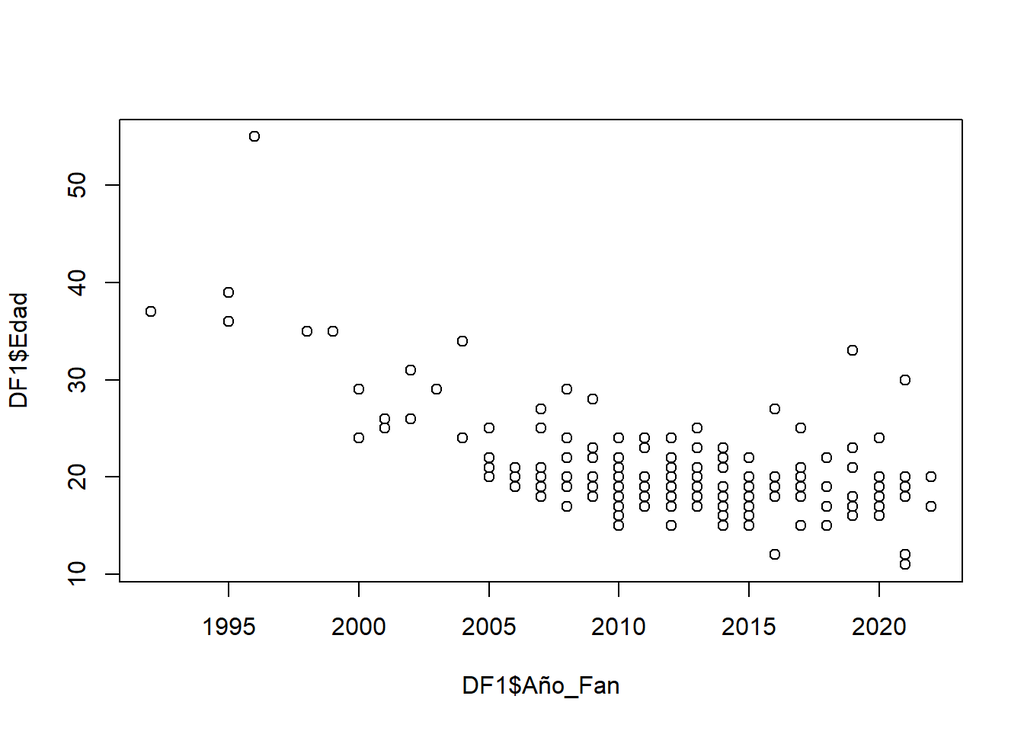

```r
plot(DF1$Año_Fan, DF1$Edad)
```

```r
summary(lm(DF1$Año_Fan~DF1$Edad))
```

```
##
## Call:
## lm(formula = DF1$Año_Fan ~ DF1$Edad)
##
## Residuals:
##     Min      1Q  Median      3Q     Max
## -9.9263 -3.5472 -0.2713  3.4270 15.5912
##
## Coefficients:
##               Estimate Std. Error t value Pr(>|t|)
## (Intercept) 2027.30630    1.42531 1422.37   <2e-16 ***
## DF1$Edad      -0.72417    0.06711  -10.79   <2e-16 ***
## ---
## Signif. codes:  0 '***' 0.001 '**' 0.01 '*' 0.05 '.' 0.1 ' ' 1
##
## Residual standard error: 4.838 on 200 degrees of freedom
##   (15 observations deleted due to missingness)
## Multiple R-squared:  0.368,  Adjusted R-squared:  0.3648
## F-statistic: 116.4 on 1 and 200 DF,  p-value: < 2.2e-16
```

*Conclusión:*A partir del analisis de los datos ofrecidos por R^2 = 36.8% no podemos afirmar que exista dicha relacion a pesar de lo que se puede ver en la grafica de dispersion

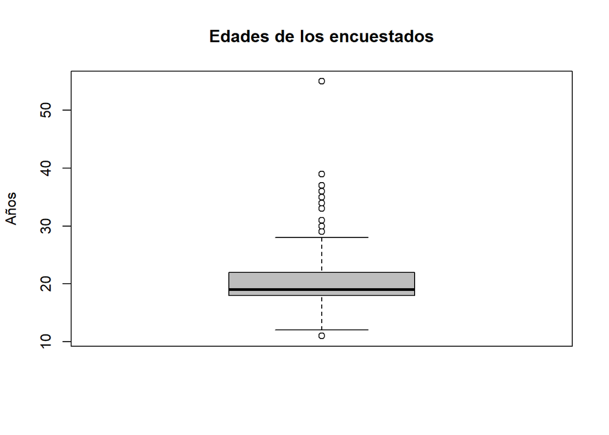

```r
boxplot(DF1$Edad,col="gray", main="Edades de los encuestados", ylab="Años")
abline(h=mean(DF1$Edad),col="red",lwd=2)
```

## *Porcentaje - Pie*

```r
a = table(DF1$Otaku)
a
```

```
##
##  No  Sí
## 137  65
```

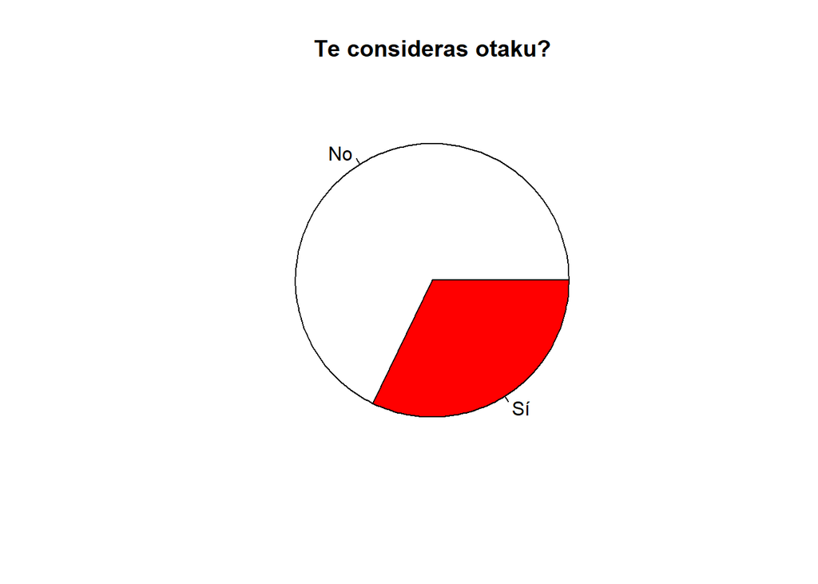

```r
pie(a, col=c("white","red"), main="Te consideras otaku?")
```

```r
b = table(DF1$Otaku, DF1$Sexo)
b
```

```
##
##      Femenino Masculino No binario Prefiero no decirlo
##   No       64        68          5                   0
##   Sí       33        26          5                   1
```

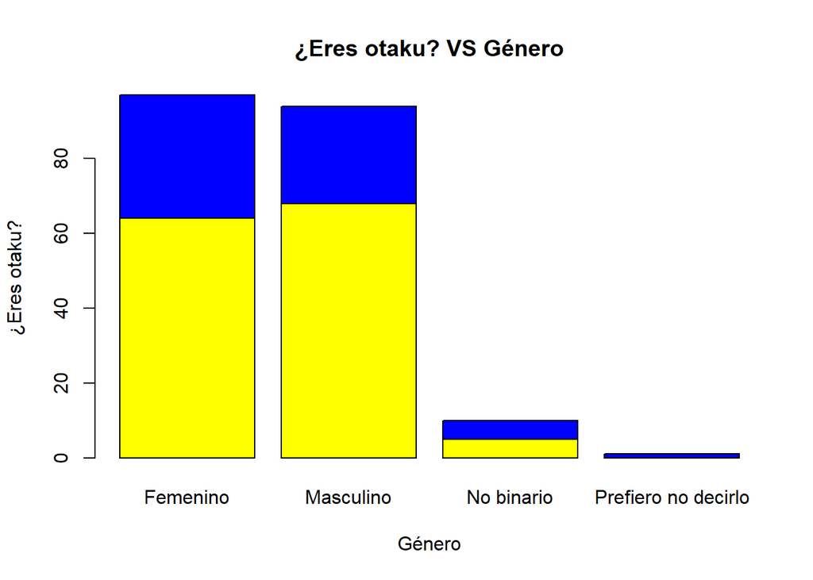

```r
barplot(b, col=c("yellow","blue"),main="¿Eres otaku? VS Género",xlab="Género",ylab="¿Eres otaku?")
```

```r
round(b/rowSums(b)*100,digits=2)
```

```
##
##      Femenino Masculino No binario Prefiero no decirlo
##   No    46.72     49.64       3.65                0.00
##   Sí    50.77     40.00       7.69                1.54
```

## *Comparación entre 2 grupos de variables - Barplot*

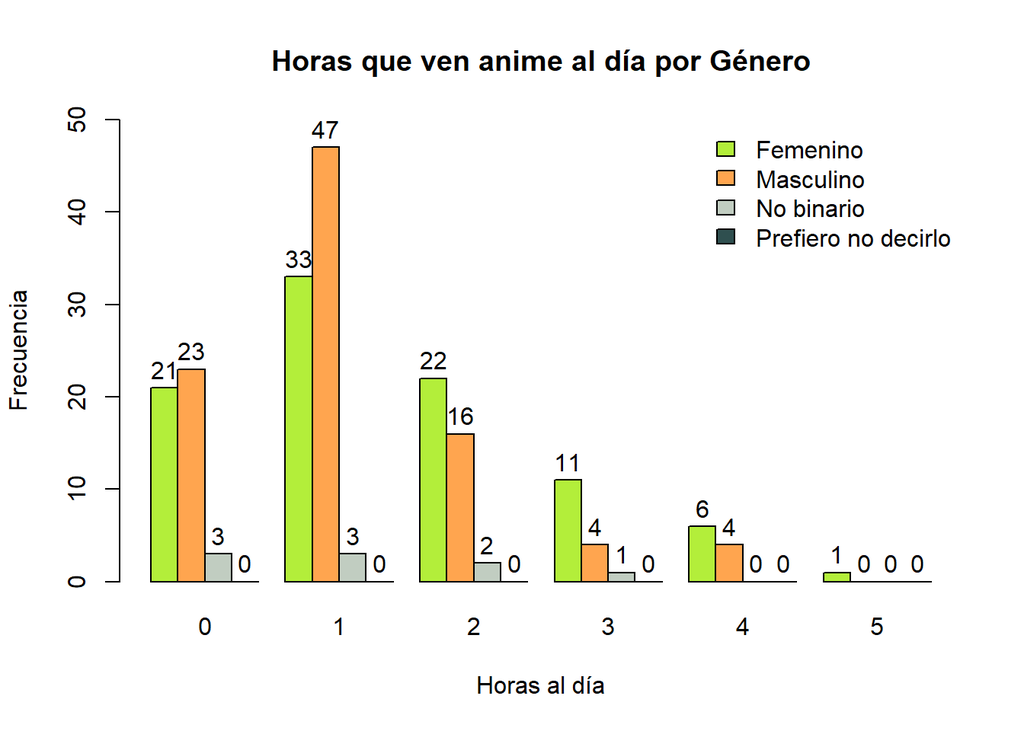

```r
tabla1 <- table(DF1$Sexo,as.numeric(DF1$Cantidad_Horas))

barp <- barplot(tabla1,beside=TRUE, col =c("#B3EE3A", "#FFA54F","honeydew3","darkslategray"),
      main = "Horas que ven anime al día por Género",
      xlab = "Horas al día",ylab = "Frecuencia",ylim=c(0,50))

legend('topright', legend=rownames(tabla1), bty='n',
       fill=c("#B3EE3A", "#FFA54F","honeydew3","darkslategray"))
text(barp, tabla1 + 2, labels = tabla1)
```

*Conclusión:* Como sé puede observar es falso el estereotipo de “los fans de anime ven todo el tiempo anime”. Con este gráfico se evidencia que un grupo no ve animes a diario. Mientras que las personas que den 1 hora diaria en su mayoria son hombres. En el caso de las 2 horas diarias las mujeres son las más predispuestas. Se podria concluir que los fans de anime hombres (47) están dispuestos a usar 1 hora diaria a ver animes, mientras que las mujeres (40) prefieren ver más de 2 horas diarias.

## *Comparacion de frecuencia - Barplot*

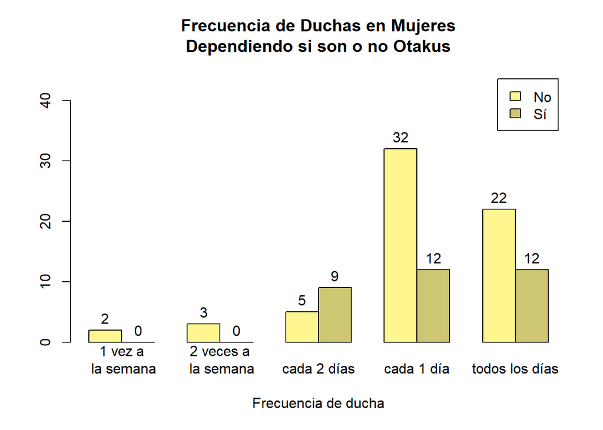

```r
tabla2 <- table(DF1$Otaku[DF1$Sexo=="Femenino"],DF1$Ducha[DF1$Sexo=="Femenino"])
barp2 <- barplot(tabla2, beside =TRUE,col=c("khaki1","khaki3"),
        xlab="Frecuencia de ducha",
        names.arg = c("1 vez a\n la semana", "2 veces a\n la semana", "cada 2 días", "cada 1 día", "todos los días"),
        main="Frecuencia de Duchas en Mujeres\nDependiendo si son o no Otakus", legend.text = rownames(tabla2), ylim=c(0,45))
text(barp2, tabla2 + 2, labels = tabla2)
```

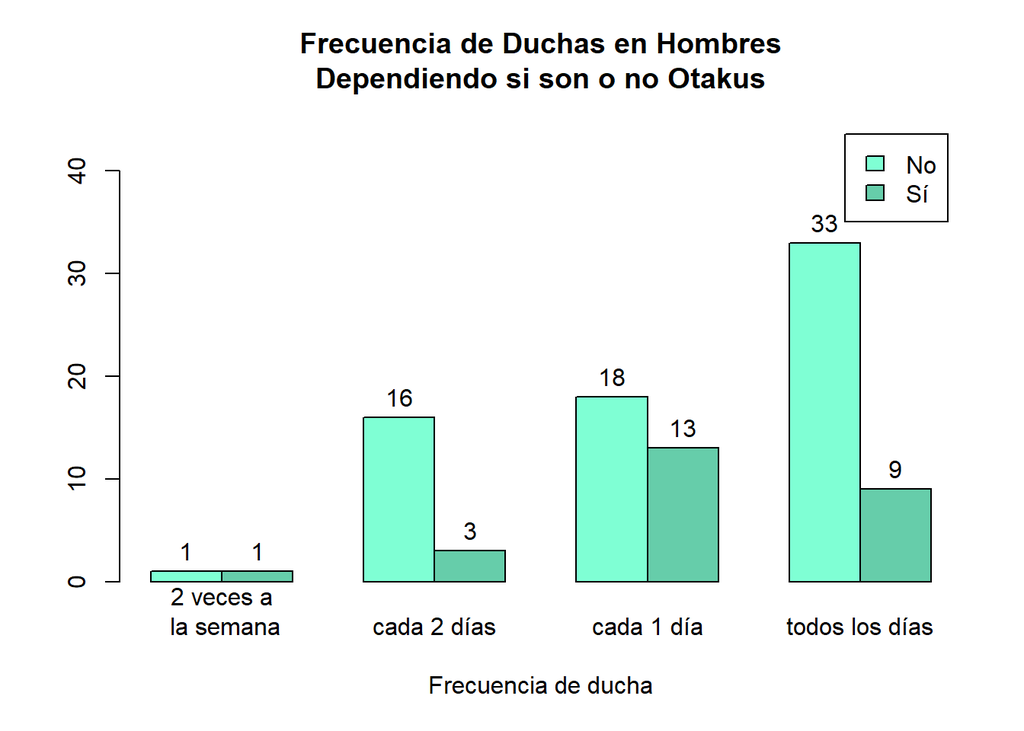

```r
tabla3 <- table(DF1$Otaku[DF1$Sexo=="Masculino"],DF1$Ducha[DF1$Sexo=="Masculino"])
barp3 <- barplot(tabla3, beside =TRUE,col=c("aquamarine1","aquamarine3"),
        xlab="Frecuencia de ducha",
        names.arg = c("2 veces a\n la semana", "cada 2 días", "cada 1 día", "todos los días"),
        main="Frecuencia de Duchas en Hombres\nDependiendo si son o no Otakus", legend.text = rownames(tabla2), ylim=c(0,45))
text(barp3, tabla3 + 2, labels = tabla3)
```

*Conclusión:* El 45% de mujeres se bañan dejando un dia. En el caso de los Hombres el 46% se bañan todos los días. Además que los que se bañan con menos frecuencia durante la semana, son aquellos que no son otakus. Lo curioso es que las mujeres otakus se bañan como minimo cada 2 días a la semana.

# *Probabilidades*

## *Caso 1:*

De la variable *Otaku* sabemos que las probabilidades son las siguientes:

```
##
##        No        Sí
## 0.6313364 0.2995392
```

Luego obtenemos las probabilidades de las frecuencias con las que se duchan:

```
##
##               1          2          3          4          5
##   No 0.01459854 0.02919708 0.16058394 0.36496350 0.43065693
##   Sí 0.00000000 0.03076923 0.20000000 0.43076923 0.33846154
```

*Conclusión:* La probabilidad de que un entrevistado que se considera otaku no se bañe es *0*

## *Caso 2:*

Tenemos una poblacion de mas de 200 personas, calcular la probabilidad de que al escoger una al azar esta sea mujer, otaku y que ademas se encuentre en una relación

[figure not shown]

Fig. : Arbol de Probabilidades